# Transmission Type and Fuel Efficiency

Alyssa Goldberg

January 10, 2016

# Executive Summary

## Hypotheses and Questions

Using the mtcars dataset from a 1974 Motor Trend US magazine, we examine the following hypotheses: $H_0$ = There is no significant difference in fuel efficiency between cars with **automatic** and **manual** transmission. $H_01$ = There are no confounding variables that contribute to the acceptance or rejection of $H_0$.

1. Is an automatic or manual transmission better for MPG ?
2. If so, quantify the MPG difference between automatic and manual transmissions

## Summary of Findings

*All figures are in the appendix* 1. Cars with manual transmission get **7.24** more mpg than automatic transmission when only transmission type is considered 2. Exploring regression models using multivariate analysis strongly suggests that both weight `wt`, number of cylinders `cyl` and `hp` have a significant confounding effect on fuel efficiency as it relates to transmission type.  
With other variables factored in, cars with manual transmission get an additional **1.8** mpg better than those with automatic transmission.

# Data

The data was extracted from the 1974 Motor Trend US magazine, and comprises fuel consumption and 10 aspects of automobile design and performance for 32 automobiles (1973-74 models).

Note: The 1/4 mile time `qsec` is a measure of performance rather than a manufacturing variable and thus we remove qsec from the dataset for the purposes of analysis.

## Factors and Measurements

`mpg` Miles/(US) gallon (the measure of, performance we are interested in), `disp` Displacement (cu.in.), `hp` Gross horsepower, `drat` Rear axle ratio, `wt` Weight (lb/1000), `qsec` 1/4 mile time, `cyl` Number of cylinders, `vs` V/S, `am` Transmission (0 = automatic, 1 = manual), `gear` Number of forward gears, `carb` Number of carburetors.

Figure 1 and Table 1 (below) include only `mpg` and `am` indicate that manual transmission has a mean mpg 7.245 automatic.

A t-test of `mpg` and `am` can reveal both the confidence interval and p-values for the two factors in the `am` variable:

```r
t.test(mtcars[,-7]$mpg~mtcars[,-7]$am)
```

```
##
##  Welch Two Sample t-test
##
## data:  mtcars[, -7]$mpg by mtcars[, -7]$am
## t = -3.7671, df = 18.332, p-value = 0.001374
## alternative hypothesis: true difference in means is not equal to 0
## 95 percent confidence interval:
##  -11.280194  -3.209684
## sample estimates:
## mean in group Automatic    mean in group Manual
##                17.14737                24.39231
```

The CI, -11.2801944, -3.2096842, does not contain zero *and* a p-value of 0.0013736, significantly better than our 95% confidence level $alpha = 0.05%.$. If the only two variable measured were fuel efficiency and transmission type, we could safely reject $H_0$.

There are 8 additional manufacturing variables in the data set and the adjusted $R^2$ for `mpg~am` is low, only 0.338, so transmission alone accounts for only 33.85% of the total effect. We need to find a better model.

```r
kable(xt, caption = "Table 1: Linear Regression Coefficients for Automatic vs. Manual Transmission")
```

Table 1: Linear Regression Coefficients for Automatic vs. Manual Transmission

|  | Estimate | Std. Error | t value | Pr(>\|t\|) |
| --- | --- | --- | --- | --- |
| (Intercept) | 17.147368 | 1.124602 | 15.247492 | 0.000000 |
| amManual | 7.244939 | 1.764422 | 4.106127 | 0.000285 |

Figure 2 shows that `cyl`, `disp`, `wt` and `hp` all have a negative effect on fuel efficiency.

# Find the Best Model

## Step Analysis for AIC

We employ R’s step() function to find the model with the lowest AIC. (results hidden to limit length of report) and produce a table comparing our three models, `mpg ~ am`, `mpg ~ .` and the result of the step analysis, `mpg ~ cyl + hp + wt + am`.

```r
fitAIC=extractAIC(lm(mpg ~ am, mtcars[,-7]))
allAIC=extractAIC(lm(mpg ~ ., mtcars[,-7]))
bestAIC=extractAIC(lm(mpg ~ cyl + hp + wt + am, mtcars[,-c(7)]))
tblAIC<-as.data.frame(rbind("mpg ~ am"= fitAIC[2],"mpg ~ ." = allAIC[2],"mpg ~ cyl + hp + wt + am" = bestAIC[2]))
names(tblAIC)<-"AIC"
kable(tblAIC, caption = "Comparison of AIC Values of Three Models")
```

Comparison of AIC Values of Three Models

|  | AIC |
| --- | --- |
| mpg ~ am | 103.67231 |
| mpg ~ . | 74.73161 |
| mpg ~ cyl + hp + wt + am | 61.65483 |

The model which includes: mpg`~`cyl + hp + wt + am has the lowest AIC value of 61.654829 and is recommended as the best fit by the step analysis. A summary of the best fit model coefficients confirm we are moving in the right direction. The net influence of the `am` variable when `am` = 1 (manual transmission) is 1.809. We will continue to test this model against the others.

|  | Estimate | Std. Error | t value | Pr(>\|t\|) |
| --- | --- | --- | --- | --- |
| (Intercept) | 33.7083239 | 2.6048862 | 12.940421 | 0.0000000 |
| cyl6 | -3.0313445 | 1.4072835 | -2.154040 | 0.0406827 |
| cyl8 | -2.1636753 | 2.2842517 | -0.947214 | 0.3522509 |
| hp | -0.0321094 | 0.0136926 | -2.345025 | 0.0269346 |
| wt | -2.4968294 | 0.8855878 | -2.819404 | 0.0090814 |
| amManual | 1.8092114 | 1.3963045 | 1.295714 | 0.2064597 |

## Analysis of Variance

An analysis of variance shows us that number of `cyl`, `wt` and `disp` are significant at a 95% confidence level, while the p-value of `hp` is higher than .05 indicating we *might* reject it as a significant factor.

```r
kable(as.data.frame(summary(aov(mpg~., data))[[1]]))
```

|  | Df | Sum Sq | Mean Sq | F value | Pr(>F) |
| --- | --- | --- | --- | --- | --- |
| cyl | 2 | 824.784590 | 412.392295 | 54.2425208 | 0.0000001 |
| disp | 1 | 57.642804 | 57.642804 | 7.5818366 | 0.0141316 |
| hp | 1 | 18.502205 | 18.502205 | 2.4336203 | 0.1383175 |
| drat | 1 | 11.914476 | 11.914476 | 1.5671272 | 0.2286170 |
| wt | 1 | 55.786898 | 55.786898 | 7.3377268 | 0.0154894 |
| vs | 1 | 1.391962 | 1.391962 | 0.1830867 | 0.6744376 |
| am | 1 | 13.368787 | 13.368787 | 1.7584147 | 0.2034425 |
| gear | 2 | 3.390542 | 1.695271 | 0.2229813 | 0.8025747 |
| carb | 5 | 17.620932 | 3.524186 | 0.4635410 | 0.7976639 |
| Residuals | 16 | 121.643991 | 7.602749 | NA | NA |

```r
kable(c4, caption = "Correlation among variables with lowest p-value in analysis of variance model")
```

Correlation among variables with lowest p-value in analysis of variance model

|  | correlation |
| --- | --- |
| wt & cyl | 0.7824958 |
| wt & disp | 0.8879799 |
| cyl & disp | 0.9020329 |

We compare several models to determine which one is truly “best” and the fourth model which retains `hp` does have the highest $R^2$: 0.8400875, accounting for 84% of the variability in fuel efficiency.

```r
kable(fitsummary)
```

|  | Adj. R-squared |
| --- | --- |
| mpg ~ . | 0.8015942 |
| mpg ~ am | 0.3384589 |
| mpg ~ cyl + wt + am | 0.8121603 |
| mpg ~ cyl + hp + wt + am | 0.8400875 |

The table below generated with R’s bootstrap function lists the relative importance of each variable and how much it contributes to the final $R^2$ value of 84%.

```r
kable(btbl,caption = "% contribution to R-squared value of best fit model" )
```

% contribution to R-squared value of best fit model

|  | % Contribution |
| --- | --- |
| cyl | 32.12 |
| hp | 29.59 |
| wt | 24.80 |
| am | 13.49 |

## Residuals

The Residual Plots (Figure 4) confirm our model in the following ways: 1. Residuals vs. Fitted plot points are randomly distributed confirming independence. 2. Points on the Normal Q-Q plot hug the normal line with some outliers in the tails confirming normal distribution of the residuals. 3. The Scale-Location plot displays a regular band pattern of points confirming constant variance.

# Appendix

figure 1: Boxplot mpg ~ am (mpg vs transmission type)

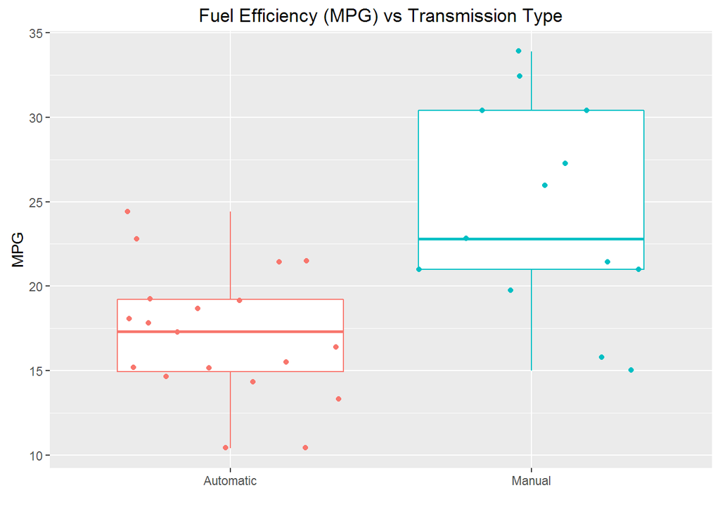

Figure 2: Pairs Plot

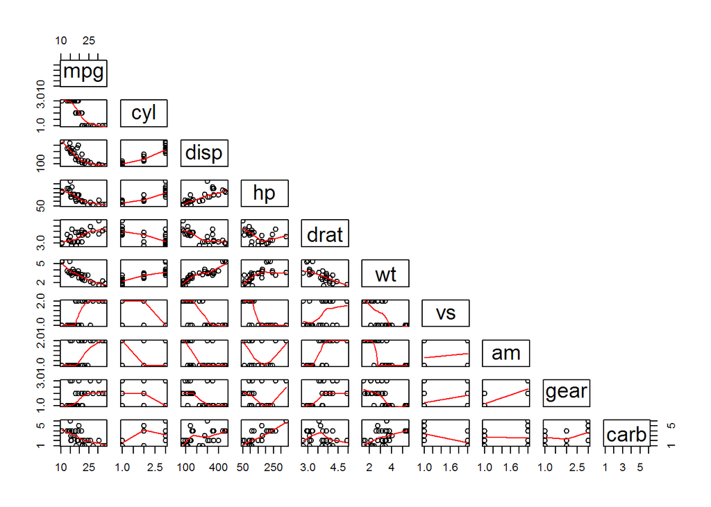

Figure 3: Correlation Matrix

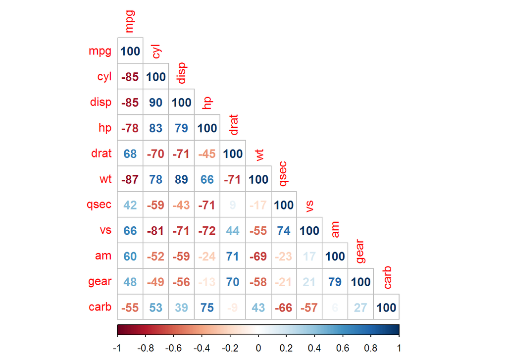

Figure 4: Residual Plots

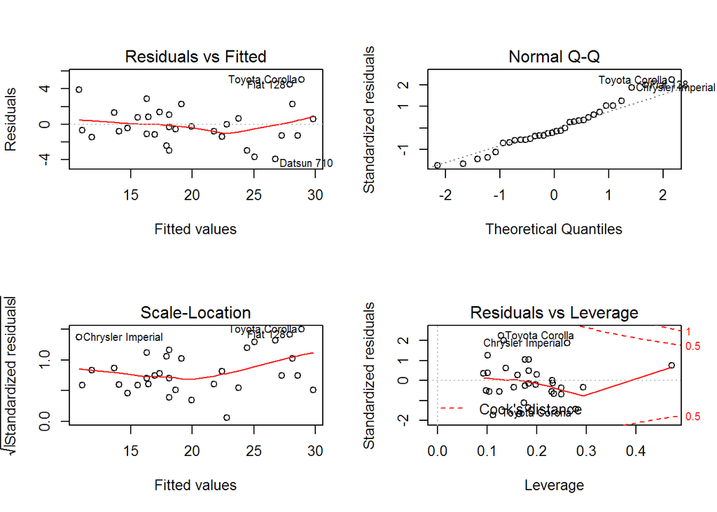